# gretlR Package: Integration of R and gretl

Sagiru Mati (PhD)

# 1 About gretlR

gretlR is an R package that can run `gretl` program from R Markdown.

# 2 Installation

gretlR can be installed using the following commands in R.

```r
install.packages("gretlR")

          OR

devtools::install_github('sagirumati/gretlR')
```

# 3 Usage

Please load the gretlR package as follows:

````
```{r gretlR}
library(gretlR)
```
````

Then create a chunk for `gretl` as shown below:

````
```{gretl gretlR1,eval=T,echo=T,comment=NULL,results='hide'}
nulldata 500
set seed 13
gretl1 = normal()
gretl2 = normal()
setobs 12 1980:01 --time-series
gnuplot gretl1 --time-series --with-lines --output="line.png"
gnuplot gretl2 gretl1 --output="scatter.png"
ols gretl1 const gretl2
modeltab add
tabprint --output="ols.Rmd"
eqnprint --output="olsmodel.Rmd"
tabprint --output="ols.csv"
```
````

The above chunk creates an gretl program with the chunk’s content, then automatically gretl, which will save gretl outputs in the current directory.

We can *dynamically and reproducibly* fetch the `gretl` graph object we created with the `gretl` chunk using the following R chunk:

For the scatter graph:

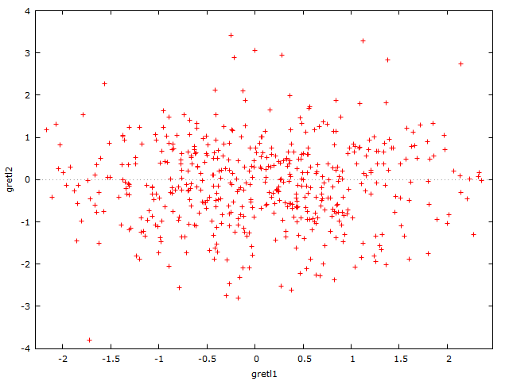

Figure 3.1: Scatter graph produced by gretl chunk

```r
library(knitr)
knitr::include_graphics("scatter.png")
```

or the line graph:

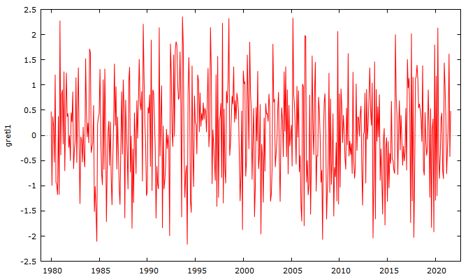

Figure 3.2: Line graph produced by gretl chunk

```r
knitr::include_graphics("line.png")
```

we can also include the equation of the OLS generated by the `gretl` chunk using the following R chunk;

Remember the OLS equation output is saved by the `gretl` chunk as `olsmodel.Rmd`. The entire OLS equation model:

````
```{r child, child='olsmodel.Rmd'}

```
````

$$\begin{gather}
\widehat{\rm gretl1} =
\underset{(0.043179)}{0.0610266}
+\underset{(0.042056)}{0.0239587}\,\mbox{gretl2}
\notag \\
T = 500 \quad \bar{R}^2 = -0.0014 \quad F(1,498) = 0.32454 \quad \hat{\sigma} = 0.96025 \notag \\
\centerline{(standard errors in parentheses)} \notag
\end{gather}$$

Remember the OLS table output is saved by `gretl` chunk as `ols.Rmd`. The entire OLS table output:

[output not shown]

Unfortunately, user of `gretl` has little or no control over the outputs customisation before exporting.

Please visit my [Github](https://github.com/sagirumati/gretlR/tree/master/inst/examples/) for a better explanation and example files.